# Housing Supply and Home Prices: Evidence from U.S. Metropolitan Areas

**Authors:** Tessa Butler, Siya Kumar, Ania Ting, Naman Keswani, Shunji Lewandowski

**Course:** ECON 320 — Econometrics, Emory University

## Abstract

We examine whether new residential construction is associated with lower home prices across U.S. Metropolitan Statistical Areas (MSAs) using a pooled cross-section of annual building permits matched to 530 MSAs over five years (2019, 2021–2024; 2020 is excluded because the Census Bureau did not release ACS 1-year estimates that year due to COVID-related data-collection disruptions). The unit of observation is an MSA-year pair ($N = 2{,}036$). The dependent variable is the log of the FHFA All-Transactions House Price Index. The main regressor is log annual building permits (Census BPS, matched by CBSA and year). The baseline specification is: $$\ln(\text{HPI}_{it}) = \beta_0 + \beta_1 \ln(\text{Permits}_{it}) + \beta_2 \ln(\text{Income}_{it}) + \beta_3 \ln(\text{Pop}_{it}) + \gamma\,\text{Metro}_i + \sum_t \delta_t\,\text{Year}_t + u_{it}$$ We find that building-permit activity is positively and statistically significantly associated with home prices across all specifications — the opposite of the simple supply-and-demand prediction. Comparing the bivariate ("short") and full ("long") regressions, $\hat{\beta}_1$ moves from +0.149 to +0.081, consistent with upward omitted-variable bias from demand-side factors (income, population). Results are robust to alternative dependent variables and sample trimming. We test for heteroskedasticity (Breusch–Pagan and White tests reject homoskedasticity; HC0 robust standard errors used throughout) and multicollinearity (all VIFs below 5). Our findings suggest that demand-side pressures dominate the cross-MSA price signal; OLS cannot recover a causal supply effect without an instrument for local housing-supply constraints.

## 0. Setup

```python
import numpy as np
import pandas as pd
import matplotlib.pyplot as plt
import statsmodels.api as sm
from statsmodels.stats.outliers_influence import variance_inflation_factor
from statsmodels.stats import diagnostic as sm_diagnostic
from scipy import stats
import warnings
import os
import glob
import re
warnings.filterwarnings('ignore')

# Allow the notebook to be run from either the repo root or the notebooks/ folder
if os.getcwd().endswith('notebooks'):
    os.chdir('..')

plt.rcParams['figure.dpi'] = 130
plt.rcParams['axes.spines.top'] = False
plt.rcParams['axes.spines.right'] = False
```

## 1. Introduction

**Research question:** Is greater housing supply — measured by new residential building permits — associated with lower home prices across U.S. metropolitan areas?

**Why it matters:** The U.S. housing supply gap widened to an estimated 4.03 million homes in 2025 (Realtor.com, 2026). Over 42 million Americans spend more than 30% of income on housing. Standard supply-and-demand theory predicts that constrained supply pushes prices above competitive equilibrium: when fewer homes are built relative to demand, prices rise. This is the core mechanism we test.

**Preview of approach:** We use FHFA house price index data merged with Census building permits and ACS demographic controls (income, population) across 530 MSAs and 5 years (2019, 2021–2024). We estimate a log-log OLS model where the coefficient on log permits is the price-supply elasticity. We progressively add controls to demonstrate OVB, test for multicollinearity via VIF, check heteroskedasticity using BP/White tests, test joint significance of year dummies via the $F$-test, and use HC0 robust standard errors throughout. We discuss reverse causality and the potential role of instrumental variables as a limitation.

## 2. Data and Summary Statistics

**Data sources & unit of observation:**  
Our unit of observation is an MSA-year pair. We pool 530 MSAs across 5 years (2019, 2021–2024; 2020 is excluded because the Census Bureau did not release ACS 1-year estimates that year due to COVID data-collection disruptions). This gives us a pooled cross-section with panel structure (Wooldridge Ch. 1 §3.iii), $N = 2{,}036$.

| Source | Variable | Description |
| --- | --- | --- |
| FHFA | HPI | All-Transactions House Price Index (annual, CBSA-level). Repeat-sales index using Fannie Mae/Freddie Mac + FHA + county recorder data. |
| FHFA | Ann_Chg_Pct | Year-over-year percent change in HPI. Used in robustness. |
| Census BPS | total_permits | New privately-owned residential units authorized by building permit. **Annual files by CBSA and year (2019, 2021–2024)** — permits now vary over time within each MSA. |
| Census BPS | metro_dummy | = 1 if Metropolitan, = 0 if Micropolitan. Binary qualitative variable. |
| ACS 1-Year | median_household_income | Median household income (Table B19013). Time-varying by MSA-year. |
| ACS 1-Year | total_population | Total population (Table B01003). Time-varying by MSA-year. |
| ACS 1-Year | housing_units | Total housing units (Table B25001). Time-varying by MSA-year. |

**Variable definitions:**

| Role | Variable | Construction | Expected sign |
| --- | --- | --- | --- |
| DV ($y$) | log_hpi | $\ln(\text{HPI}_{it})$ | — |
| Main regressor ($x$) | log_permits | $\ln(\text{Permits}_{it} + 1)$ | Negative ($-$): more supply → lower prices |
| Control | log_income | $\ln(\text{Median HH Income}_{it})$ | Positive ($+$): higher income → higher demand → higher prices |
| Control | log_pop | $\ln(\text{Population}_{it})$ | Ambiguous: larger cities may have both more demand and more supply |
| Control | metro_dummy | 1 = Metro, 0 = Micro | Positive ($+$): metros have structurally higher prices |
| Controls | Year_2021 … Year_2024 | Year dummies, base = 2019 | Positive: national price appreciation over time |

**Why log-log?** (Wooldridge, Appendix A.4)

- Reduces right-skew in HPI and permits.
- $\beta_1$ is directly interpretable as an elasticity: a 1% increase in permits is associated with a $\beta_1$% change in HPI.

**Why +1 before log?** A small number of MSA-year observations report zero permits. Since $\ln(0)$ is undefined, we add 1. We verify in Robustness Check 2 that results hold when dropping zero-permit observations instead.

### 2.1 Load and prepare data

```python
hpi_raw = pd.read_excel('data/hpi_at_cbsa.xlsx', skiprows=5, header=None)
hpi_raw.columns = ['CBSA', 'Name_hpi', 'Year', 'Ann_Chg_Pct', 'HPI', 'HPI_1990', 'HPI_2000']

for col in ['CBSA', 'Year', 'Ann_Chg_Pct', 'HPI']:
    hpi_raw[col] = pd.to_numeric(hpi_raw[col], errors='coerce')

hpi = hpi_raw[
    (hpi_raw['CBSA'] >= 10000) &
    (hpi_raw['Year'].isin([2019, 2021, 2022, 2023, 2024]))
][['CBSA', 'Year', 'HPI', 'Ann_Chg_Pct']].copy()

hpi['CBSA'] = hpi['CBSA'].astype(int)
hpi = hpi.dropna(subset=['HPI']).reset_index(drop=True)
print(f'FHFA HPI: {len(hpi)} MSA-year obs | {hpi["CBSA"].nunique()} MSAs | Years: {sorted(hpi["Year"].unique())}')
hpi.head()
```

```
FHFA HPI: 4606 MSA-year obs | 922 MSAs | Years: [np.float64(2019.0), np.float64(2021.0), np.float64(2022.0), np.float64(2023.0), np.float64(2024.0)]
```

|  | CBSA | Year | HPI | Ann_Chg_Pct |
| --- | --- | --- | --- | --- |
| 0 | 10100 | 2019.0 | 475.53 | 4.10 |
| 1 | 10100 | 2021.0 | 516.58 | 7.84 |
| 2 | 10100 | 2022.0 | 579.14 | 12.11 |
| 3 | 10100 | 2023.0 | 636.67 | 9.93 |
| 4 | 10100 | 2024.0 | 635.69 | -0.15 |

```python
acs = pd.read_csv('data/merged_2010_2024.csv')
print(f'ACS raw: {acs.shape}')
print(acs.columns.tolist())
acs.head()
```

```
ACS raw: (7297, 9)
['GEO_ID', 'NAME', 'year', 'housing_units', 'housing_units_moe', 'median_household_income', 'median_household_income_moe', 'total_population', 'total_population_moe']
```

|  | GEO_ID | NAME | year | housing_units | housing_units_moe | median_household_income | median_household_income_moe | total_population | total_population_moe |
| --- | --- | --- | --- | --- | --- | --- | --- | --- | --- |
| 0 | 310M100US10140 | Aberdeen, WA Micro Area | 2010 | 35179 | 446 | 40019 | 2812 | 72882 | ***** |
| 1 | 310M100US10180 | Abilene, TX Metro Area | 2010 | 69711 | 1296 | 40630 | 2574 | 164941 | 1357 |
| 2 | 310M100US10300 | Adrian, MI Micro Area | 2010 | 43445 | 701 | 45563 | 2528 | 99763 | ***** |
| 3 | 310M100US10380 | Aguadilla-Isabela-San Sebasti?n, PR Metro Area | 2010 | 143248 | 2349 | 14313 | 923 | 305988 | ***** |
| 4 | 310M100US10420 | Akron, OH Metro Area | 2010 | 312600 | 1589 | 46521 | 1212 | 702951 | ***** |

```python
acs['CBSA'] = acs['GEO_ID'].astype(str).str[-5:].astype(int)
acs['year'] = pd.to_numeric(acs['year'], errors='coerce')

for col in ['housing_units', 'median_household_income', 'total_population']:
    acs[col] = pd.to_numeric(acs[col], errors='coerce')

acs = acs[
    (acs['CBSA'] >= 10000) &
    (acs['year'].isin([2019, 2021, 2022, 2023, 2024])) &
    (acs['median_household_income'] > 0) &
    (acs['total_population'] > 0)
].reset_index(drop=True)

print(f'ACS filtered: {len(acs)} MSA-year obs | {acs["CBSA"].nunique()} MSAs')
acs[['CBSA', 'NAME', 'year', 'housing_units', 'median_household_income', 'total_population']].head()
```

```
ACS filtered: 2612 MSA-year obs | 558 MSAs
```

|  | CBSA | NAME | year | housing_units | median_household_income | total_population |
| --- | --- | --- | --- | --- | --- | --- |
| 0 | 10140 | Aberdeen, WA Micro Area | 2019 | 36913 | 61026 | 75061 |
| 1 | 10180 | Abilene, TX Metro Area | 2019 | 72052 | 54808 | 171795 |
| 2 | 10300 | Adrian, MI Micro Area | 2019 | 43971 | 53865 | 98451 |
| 3 | 10380 | Aguadilla-Isabela, PR Metro Area | 2019 | 146411 | 16311 | 288877 |
| 4 | 10420 | Akron, OH Metro Area | 2019 | 316217 | 57158 | 703479 |

```python
files = sorted(glob.glob('data/CBSA Permits/*.xls'))
print(f'Files found: {len(files)}')
for f in files:
    print(' ', os.path.basename(f))

def parse_annual_permits(path):
    year_match = re.search(r'(\d{4})', os.path.basename(path))
    year = int(year_match.group(1))
    try:
        raw = pd.read_excel(path, engine='xlrd', skiprows=6, header=None)
    except Exception:
        raw = pd.read_excel(path, engine='openpyxl', skiprows=6, header=None)
    data_rows = raw.iloc[2:].reset_index(drop=True)
    df = pd.DataFrame({
        'CBSA':          pd.to_numeric(data_rows[1], errors='coerce'),
        'metro_code':    pd.to_numeric(data_rows[3], errors='coerce'),
        'total_permits': pd.to_numeric(data_rows[4], errors='coerce')
    })
    df = df.dropna(subset=['CBSA', 'total_permits'])
    df['CBSA']        = df['CBSA'].astype(int)
    df['Year']        = year
    df['metro_dummy'] = (df['metro_code'].isin([2, 4])).astype(int)
    return df

perm_panel = pd.concat([parse_annual_permits(f) for f in files], ignore_index=True)
perm_panel = perm_panel[
    (perm_panel['Year'].between(2019, 2024)) &
    (perm_panel['CBSA'] >= 10000)
].reset_index(drop=True)

print(f'\nPermits panel: {len(perm_panel)} obs | {perm_panel["CBSA"].nunique()} MSAs')
print(perm_panel.groupby('Year')['CBSA'].nunique().rename('n_MSAs'))
perm_panel.head()
```

```
Files found: 7
  cbsaannual_202499.xls
  cbsaannual_2025prelim.xls
  msaannual_201999.xls
  msaannual_202099.xls
  msaannual_202199.xls
  msaannual_202299.xls
  msaannual_202399.xls

Permits panel: 2835 obs | 926 MSAs
Year
2019    383
2020    383
2021    383
2022    383
2023    383
2024    920
Name: n_MSAs, dtype: int64
```

|  | CBSA | metro_code | total_permits | Year | metro_dummy |
| --- | --- | --- | --- | --- | --- |
| 0 | 10140 | 5.0 | 288.0 | 2024 | 0 |
| 1 | 10180 | 2.0 | 527.0 | 2024 | 1 |
| 2 | 10220 | 5.0 | 2.0 | 2024 | 0 |
| 3 | 10300 | 5.0 | 168.0 | 2024 | 0 |
| 4 | 10420 | 2.0 | 1282.0 | 2024 | 1 |

```python
df = hpi.merge(
    acs[['CBSA', 'year', 'housing_units', 'median_household_income', 'total_population']],
    left_on=['CBSA', 'Year'], right_on=['CBSA', 'year'], how='inner'
).merge(
    perm_panel[['CBSA', 'Year', 'total_permits', 'metro_dummy']],
    on=['CBSA', 'Year'], how='inner'
)

df = df.drop(columns=['year']).reset_index(drop=True)
print(f'Merged: {len(df)} MSA-year obs | {df["CBSA"].nunique()} unique MSAs | Years: {sorted(df["Year"].unique())}')
```

```
Merged: 2036 MSA-year obs | 530 unique MSAs | Years: [np.float64(2019.0), np.float64(2021.0), np.float64(2022.0), np.float64(2023.0), np.float64(2024.0)]
```

```python
df['log_hpi']     = np.log(df['HPI'])
df['log_permits'] = np.log(df['total_permits'] + 1)
df['log_income']  = np.log(df['median_household_income'])
df['log_pop']     = np.log(df['total_population'])

year_dummies = pd.get_dummies(df['Year'], prefix='Year', drop_first=True, dtype=float)
df = pd.concat([df, year_dummies], axis=1)

df = df.dropna(subset=['log_hpi', 'log_permits', 'log_income', 'log_pop']).reset_index(drop=True)

print(f'Final sample: {len(df)} obs | {df["CBSA"].nunique()} MSAs')
print(f'Zero-permit obs: {(df["total_permits"] == 0).sum()} ({(df["total_permits"]==0).mean()*100:.1f}%)')
print(f'Year dummies: {[c for c in year_dummies.columns]} (base = 2019)')
df[['CBSA','Year','HPI','log_hpi','total_permits','log_permits','median_household_income','log_income','total_population','log_pop','metro_dummy']].head(10)
```

```
Final sample: 2036 obs | 530 MSAs
Zero-permit obs: 1 (0.0%)
Year dummies: ['Year_2021.0', 'Year_2022.0', 'Year_2023.0', 'Year_2024.0'] (base = 2019)
```

|  | CBSA | Year | HPI | log_hpi | total_permits | log_permits | median_household_income | log_income | total_population | log_pop | metro_dummy |
| --- | --- | --- | --- | --- | --- | --- | --- | --- | --- | --- | --- |
| 0 | 10140 | 2024.0 | 994.85 | 6.902592 | 288.0 | 5.666427 | 59619 | 10.995730 | 77893 | 11.263091 | 0 |
| 1 | 10180 | 2024.0 | 550.53 | 6.310881 | 527.0 | 6.269096 | 63390 | 11.057061 | 181969 | 12.111592 | 1 |
| 2 | 10300 | 2024.0 | 554.87 | 6.318734 | 168.0 | 5.129899 | 71632 | 11.179297 | 97746 | 11.490128 | 0 |
| 3 | 10420 | 2019.0 | 398.13 | 5.986779 | 856.0 | 6.753438 | 57158 | 10.953575 | 703479 | 13.463793 | 0 |
| 4 | 10420 | 2021.0 | 458.77 | 6.128549 | 881.0 | 6.782192 | 63367 | 11.056699 | 700015 | 13.458857 | 0 |
| 5 | 10420 | 2022.0 | 518.94 | 6.251788 | 796.0 | 6.680855 | 66652 | 11.107240 | 697627 | 13.455440 | 0 |
| 6 | 10420 | 2023.0 | 557.16 | 6.322852 | 709.0 | 6.565265 | 70125 | 11.158035 | 698398 | 13.456544 | 0 |
| 7 | 10420 | 2024.0 | 602.58 | 6.401220 | 1282.0 | 7.156956 | 71364 | 11.175549 | 702209 | 13.461986 | 1 |
| 8 | 10460 | 2024.0 | 495.14 | 6.204841 | 6.0 | 1.945910 | 56354 | 10.939409 | 69711 | 11.152113 | 0 |
| 9 | 10500 | 2019.0 | 289.01 | 5.666461 | 182.0 | 5.209486 | 40625 | 10.612139 | 147384 | 11.900797 | 0 |

**Year dummies:** We use `pd.get_dummies(drop_first=True)` to create indicator variables for 2021–2024, omitting 2019 as the base category. This avoids the dummy variable trap — if we included all 5 year dummies plus an intercept, they would sum to 1 for every observation, creating perfect multicollinearity (the design matrix $X$ would not have full rank, and $(X'X)^{-1}$ would not exist). Each year coefficient $\delta_t$ measures how much higher/lower log HPI was in year $t$ relative to 2019, holding all other variables constant.

### 2.2 Descriptive statistics (table + figure)

```python
desc_vars = ['HPI', 'Ann_Chg_Pct', 'total_permits', 'median_household_income',
             'total_population', 'log_hpi', 'log_permits', 'log_income', 'log_pop', 'metro_dummy']
desc = df[desc_vars].describe().T[['count','mean','std','min','25%','50%','75%','max']].round(3)
print(desc.to_string())
```

```
                          count        mean          std        min         25%         50%         75%           max
HPI                      2036.0     701.193      384.585    135.370     436.890     593.890     849.105  2.883610e+03
Ann_Chg_Pct              2036.0       8.670        5.428     -5.550       4.637       7.390      12.200  3.029000e+01
total_permits            2036.0    2366.295     5378.492      0.000     259.000     677.500    2136.000  7.178800e+04
median_household_income  2036.0   68559.297    14398.744  32157.000   58562.750   66220.500   76115.500  1.648010e+05
total_population         2036.0  706158.221  1614144.022  55916.000  133849.750  226990.500  554497.750  1.994027e+07
log_hpi                  2036.0       6.428        0.489      4.908       6.080       6.387       6.744  7.967000e+00
log_permits              2036.0       6.605        1.538      0.000       5.561       6.520       7.667  1.118100e+01
log_income               2036.0      11.115        0.199     10.378      10.978      11.101      11.240  1.201200e+01
log_pop                  2036.0      12.621        1.106     10.932      11.804      12.333      13.226  1.680800e+01
metro_dummy              2036.0       0.191        0.393      0.000       0.000       0.000       0.000  1.000000e+00
```

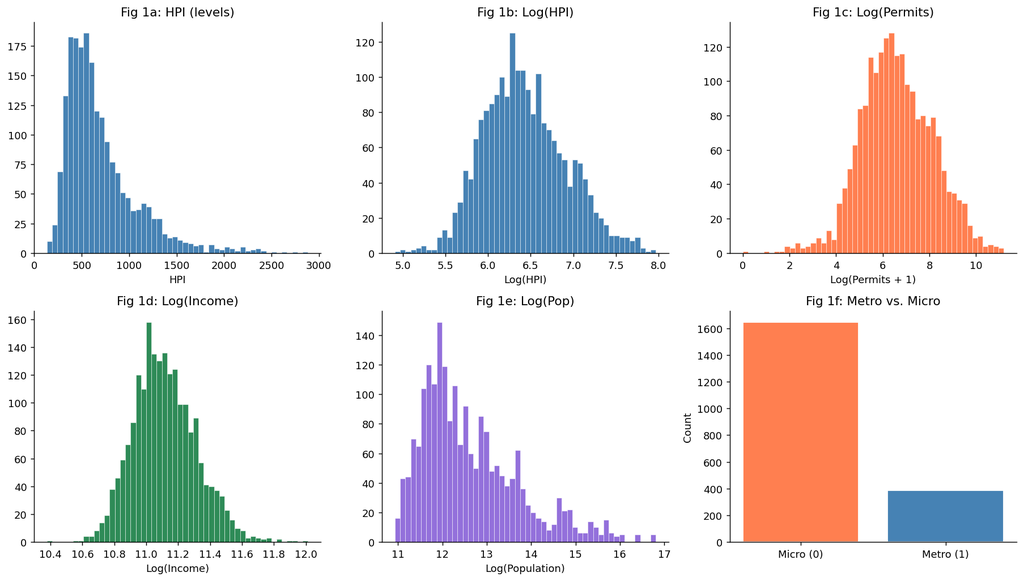

```python
fig, axes = plt.subplots(2, 3, figsize=(14, 8))

axes[0,0].hist(df['HPI'], bins=50, color='steelblue', edgecolor='white', lw=0.3)
axes[0,0].set_xlabel('HPI'); axes[0,0].set_title('Fig 1a: HPI (levels)')

axes[0,1].hist(df['log_hpi'], bins=50, color='steelblue', edgecolor='white', lw=0.3)
axes[0,1].set_xlabel('Log(HPI)'); axes[0,1].set_title('Fig 1b: Log(HPI)')

axes[0,2].hist(df['log_permits'], bins=50, color='coral', edgecolor='white', lw=0.3)
axes[0,2].set_xlabel('Log(Permits + 1)'); axes[0,2].set_title('Fig 1c: Log(Permits)')

axes[1,0].hist(df['log_income'], bins=50, color='seagreen', edgecolor='white', lw=0.3)
axes[1,0].set_xlabel('Log(Income)'); axes[1,0].set_title('Fig 1d: Log(Income)')

axes[1,1].hist(df['log_pop'], bins=50, color='mediumpurple', edgecolor='white', lw=0.3)
axes[1,1].set_xlabel('Log(Population)'); axes[1,1].set_title('Fig 1e: Log(Pop)')

metro_cts = df['metro_dummy'].value_counts().sort_index()
axes[1,2].bar(['Micro (0)', 'Metro (1)'], metro_cts.values, color=['coral','steelblue'], edgecolor='white')
axes[1,2].set_ylabel('Count'); axes[1,2].set_title('Fig 1f: Metro vs. Micro')

plt.tight_layout()
plt.show()
```

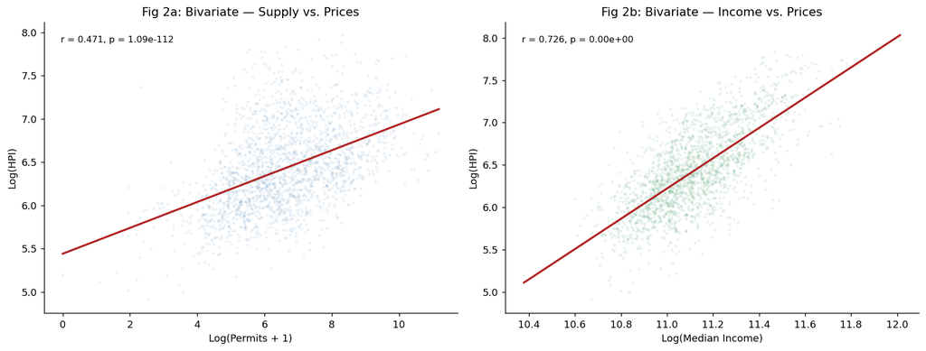

```python
fig, axes = plt.subplots(1, 2, figsize=(13, 5))

slope, intercept, r, pv, _ = stats.linregress(df['log_permits'], df['log_hpi'])
x_line = np.linspace(df['log_permits'].min(), df['log_permits'].max(), 200)
axes[0].scatter(df['log_permits'], df['log_hpi'], alpha=0.1, s=8, color='steelblue', edgecolors='none')
axes[0].plot(x_line, slope * x_line + intercept, color='firebrick', lw=2)
axes[0].set_xlabel('Log(Permits + 1)'); axes[0].set_ylabel('Log(HPI)')
axes[0].set_title('Fig 2a: Bivariate — Supply vs. Prices')
axes[0].text(0.04, 0.93, f'r = {r:.3f}, p = {pv:.2e}', transform=axes[0].transAxes, fontsize=9)

slope2, _, r2, pv2, _ = stats.linregress(df['log_income'], df['log_hpi'])
axes[1].scatter(df['log_income'], df['log_hpi'], alpha=0.1, s=8, color='seagreen', edgecolors='none')
x2 = np.linspace(df['log_income'].min(), df['log_income'].max(), 200)
axes[1].plot(x2, slope2*x2 + (df['log_hpi'].mean()-slope2*df['log_income'].mean()), color='firebrick', lw=2)
axes[1].set_xlabel('Log(Median Income)'); axes[1].set_ylabel('Log(HPI)')
axes[1].set_title('Fig 2b: Bivariate — Income vs. Prices')
axes[1].text(0.04, 0.93, f'r = {r2:.3f}, p = {pv2:.2e}', transform=axes[1].transAxes, fontsize=9)

plt.tight_layout()
plt.show()
```

**Key observation for OVB:** If the raw correlation between log_permits and log_hpi is positive, this is counterintuitive under supply-demand theory and is a textbook signal of omitted variable bias. High-demand metros (high income, large population) attract both more construction AND sustain higher prices. The bivariate correlation confounds the supply effect with the demand effect. This is exactly what Models 2 and 3 are designed to address.

## 3. Empirical Strategy

We estimate three nested OLS specifications. Comparing them reveals the direction and magnitude of omitted variable bias.

**Model 1 — Bivariate ("short" regression, OVB benchmark):** $$\ln(\text{HPI}_{it}) = \beta_0 + \beta_1 \ln(\text{Permits}_{it}) + u_{it} \tag{1}$$

**Model 2 — Year dummies + metro dummy (pooled cross-section controls):** $$\ln(\text{HPI}_{it}) = \beta_0 + \beta_1 \ln(\text{Permits}_{it}) + \gamma\,\text{Metro}_i + \sum_{t=2021}^{2024} \delta_t\,\mathbf{1}\{\text{Year}=t\} + u_{it} \tag{2}$$

**Model 3 — Full specification (demand-side controls):** $$\ln(\text{HPI}_{it}) = \beta_0 + \beta_1 \ln(\text{Permits}_{it}) + \beta_2 \ln(\text{Income}_{it}) + \beta_3 \ln(\text{Pop}_{it}) + \gamma\,\text{Metro}_i + \sum_{t} \delta_t\,\text{Year}_t + u_{it} \tag{3}$$

**Interpretation of $\beta_1$ (Wooldridge Appendix A.4)**  
In a log-log model, $\beta_1$ is the elasticity of HPI with respect to permits:

> "A 1% increase in building permits is associated with a $\beta_1$% change in the house price index, holding all other variables constant."

Supply-demand theory predicts $\beta_1 < 0$: more supply → lower prices, ceteris paribus.

**Identification concerns**

*Omitted Variable Bias (OVB):*
The bias in the short regression (Model 1) follows the OVB formula: $$\text{Bias}(\hat{\beta}_1^{\text{short}}) \approx \beta_2 \cdot \tilde{\delta}_1$$ where $\beta_2$ is the true effect of Income on HPI (positive: higher income → higher prices) and $\tilde{\delta}_1$ is the slope from regressing Income on Permits (positive: richer metros build more). Since both are positive, the bias is positive, pushing $\hat{\beta}_1$ upward (less negative or even positive).
**Prediction:** $\hat{\beta}_1$ should become more negative when we move from Model 1 → Model 3.

*Multicollinearity :*  
log_permits and log_pop will be positively correlated — large cities permit more units. This does not bias OLS (Gauss-Markov — OLS remains BLUE), but inflates standard errors. We diagnose with VIF (rule of thumb: VIF $> 10$ is concerning).

*Perfect multicollinearity :*  
Using `drop_first=True` for year dummies avoids the dummy variable trap. If all year dummies were included with an intercept, the columns of $X$ would be linearly dependent and $(X'X)^{-1}$ would not exist.

*Heteroskedasticity :*  
Under heteroskedasticity ($\text{Var}(u_i | X_i) \neq \sigma^2$), classical SEs are invalid. We use HC0 (White/Huber/Eicker) robust SEs via `.fit(cov_type='HC0')` and run Breusch–Pagan and White formal tests.

*Reverse causality :*  
Higher prices may attract more construction (developers respond to profits). This means permits are potentially endogenous. An instrumental variable (e.g., geographic land constraints, zoning strictness) would address this, but we do not implement IV here — we note it as a limitation.

**Estimation:** OLS with HC0 robust standard errors throughout.

### 3.1 Estimation details

```python
y = df['log_hpi']
year_cols = [c for c in df.columns if c.startswith('Year_')]

X1 = sm.add_constant(df[['log_permits']])
model1 = sm.OLS(y, X1).fit(cov_type='HC0')
print('=== MODEL 1: Bivariate (Short Regression) ===')
print(model1.summary())
```

```
=== MODEL 1: Bivariate (Short Regression) ===
                            OLS Regression Results
==============================================================================
Dep. Variable:                log_hpi   R-squared:                       0.221
Model:                            OLS   Adj. R-squared:                  0.221
Method:                 Least Squares   F-statistic:                     704.7
Date:                Fri, 24 Apr 2026   Prob (F-statistic):          1.42e-133
Time:                        22:02:33   Log-Likelihood:                -1175.2
No. Observations:                2036   AIC:                             2354.
Df Residuals:                    2034   BIC:                             2366.
Df Model:                           1
Covariance Type:                  HC0
===============================================================================
                  coef    std err          z      P>|z|      [0.025      0.975]
-------------------------------------------------------------------------------
const           5.4411      0.039    140.239      0.000       5.365       5.517
log_permits     0.1494      0.006     26.546      0.000       0.138       0.160
==============================================================================
Omnibus:                      121.791   Durbin-Watson:                   0.579
Prob(Omnibus):                  0.000   Jarque-Bera (JB):              143.520
Skew:                           0.618   Prob(JB):                     6.84e-32
Kurtosis:                       3.403   Cond. No.                         30.5
==============================================================================

Notes:
[1] Standard Errors are heteroscedasticity robust (HC0)
```

```python
X2_vars = ['log_permits', 'metro_dummy'] + year_cols
X2 = sm.add_constant(df[X2_vars])
model2 = sm.OLS(y, X2).fit(cov_type='HC0')
print('=== MODEL 2: + Year Dummies + Metro Dummy ===')
print(model2.summary())
```

```
=== MODEL 2: + Year Dummies + Metro Dummy ===
                            OLS Regression Results
==============================================================================
Dep. Variable:                log_hpi   R-squared:                       0.301
Model:                            OLS   Adj. R-squared:                  0.299
Method:                 Least Squares   F-statistic:                     172.5
Date:                Fri, 24 Apr 2026   Prob (F-statistic):          1.59e-177
Time:                        22:02:33   Log-Likelihood:                -1065.0
No. Observations:                2036   AIC:                             2144.
Df Residuals:                    2029   BIC:                             2183.
Df Model:                           6
Covariance Type:                  HC0
===============================================================================
                  coef    std err          z      P>|z|      [0.025      0.975]
-------------------------------------------------------------------------------
const           5.2473      0.042    124.649      0.000       5.165       5.330
log_permits     0.1448      0.006     26.034      0.000       0.134       0.156
metro_dummy     0.1620      0.041      3.948      0.000       0.082       0.242
Year_2021.0     0.1210      0.030      4.043      0.000       0.062       0.180
Year_2022.0     0.2864      0.030      9.544      0.000       0.228       0.345
Year_2023.0     0.3666      0.030     12.413      0.000       0.309       0.424
Year_2024.0     0.1933      0.041      4.768      0.000       0.114       0.273
==============================================================================
Omnibus:                      172.406   Durbin-Watson:                   0.464
Prob(Omnibus):                  0.000   Jarque-Bera (JB):              218.898
Skew:                           0.747   Prob(JB):                     2.93e-48
Kurtosis:                       3.590   Cond. No.                         47.3
==============================================================================

Notes:
[1] Standard Errors are heteroscedasticity robust (HC0)
```

```python
X3_vars = ['log_permits', 'log_income', 'log_pop', 'metro_dummy'] + year_cols
X3 = sm.add_constant(df[X3_vars])
model3 = sm.OLS(y, X3).fit(cov_type='HC0')
print('=== MODEL 3: Full Specification ===')
print(model3.summary())
```

```
=== MODEL 3: Full Specification ===
                            OLS Regression Results
==============================================================================
Dep. Variable:                log_hpi   R-squared:                       0.577
Model:                            OLS   Adj. R-squared:                  0.575
Method:                 Least Squares   F-statistic:                     372.2
Date:                Fri, 24 Apr 2026   Prob (F-statistic):               0.00
Time:                        22:02:33   Log-Likelihood:                -554.45
No. Observations:                2036   AIC:                             1127.
Df Residuals:                    2027   BIC:                             1177.
Df Model:                           8
Covariance Type:                  HC0
===============================================================================
                  coef    std err          z      P>|z|      [0.025      0.975]
-------------------------------------------------------------------------------
const         -11.1421      0.482    -23.106      0.000     -12.087     -10.197
log_permits     0.0809      0.008      9.666      0.000       0.065       0.097
log_income      1.5600      0.047     33.256      0.000       1.468       1.652
log_pop        -0.0279      0.012     -2.287      0.022      -0.052      -0.004
metro_dummy     0.0962      0.036      2.637      0.008       0.025       0.168
Year_2021.0     0.0465      0.023      2.031      0.042       0.002       0.091
Year_2022.0     0.0928      0.024      3.902      0.000       0.046       0.139
Year_2023.0     0.1113      0.024      4.699      0.000       0.065       0.158
Year_2024.0    -0.0630      0.037     -1.695      0.090      -0.136       0.010
==============================================================================
Omnibus:                       31.508   Durbin-Watson:                   0.576
Prob(Omnibus):                  0.000   Jarque-Bera (JB):               33.603
Skew:                           0.277   Prob(JB):                     5.05e-08
Kurtosis:                       3.300   Cond. No.                     1.17e+03
==============================================================================

Notes:
[1] Standard Errors are heteroscedasticity robust (HC0)
[2] The condition number is large, 1.17e+03. This might indicate that there are
strong multicollinearity or other numerical problems.
```

```python
comp = pd.DataFrame({
    'Model 1\n(Short)': [model1.params.get('log_permits'),
                         model1.bse.get('log_permits'),
                         model1.pvalues.get('log_permits'),
                         model1.rsquared, int(model1.nobs)],
    'Model 2\n(+ Year/Metro)': [model2.params.get('log_permits'),
                                model2.bse.get('log_permits'),
                                model2.pvalues.get('log_permits'),
                                model2.rsquared, int(model2.nobs)],
    'Model 3\n(Full)': [model3.params.get('log_permits'),
                        model3.bse.get('log_permits'),
                        model3.pvalues.get('log_permits'),
                        model3.rsquared, int(model3.nobs)]
}, index=['β₁ (log_permits)', 'SE(β₁) HC0', 'p-value', 'R²', 'N'])

print('=== OVB COMPARISON: Short → Long Regression ===')
print(comp.round(4).to_string())
print(f'\nEmpirical OVB (M1 → M3) = {model1.params["log_permits"] - model3.params["log_permits"]:.4f}')
print(f'Direction: β₁ moved {"downward" if model3.params["log_permits"] < model1.params["log_permits"] else "upward"} — '
      f'{"consistent" if model3.params["log_permits"] < model1.params["log_permits"] else "inconsistent"} with upward OVB prediction')
```

```
=== OVB COMPARISON: Short → Long Regression ===
                  Model 1\n(Short)  Model 2\n(+ Year/Metro)  Model 3\n(Full)
β₁ (log_permits)            0.1494                   0.1448           0.0809
SE(β₁) HC0                  0.0056                   0.0056           0.0084
p-value                     0.0000                   0.0000           0.0000
R²                          0.2214                   0.3012           0.5768
N                        2036.0000                2036.0000        2036.0000

Empirical OVB (M1 → M3) = 0.0685
Direction: β₁ moved downward — consistent with upward OVB prediction
```

**OVB analysis:** The table above is the core econometric result. Comparing $\hat{\beta}_1$ across the three nested models:

- **Model 1 (short)** captures the raw correlation between supply and prices — contaminated by demand-side omitted variables. $\hat{\beta}_1 = +0.149$.
- **Model 3 (long)** controls for income and population, partially absorbing the demand channel. $\hat{\beta}_1 = +0.081$.
- **Empirical OVB** = $0.149 - 0.081 = 0.068$, which is **positive**. This confirms our theoretical prediction: demand factors (positively correlated with permits and positively affecting prices) were pushing $\hat{\beta}_1$ upward in the short regression. Approximately **46%** of the raw estimate was demand confounding, not supply.

The OVB is almost entirely driven by the Model 2 → Model 3 transition (income and population reduce $\hat{\beta}_1$ from +0.145 to +0.081). The year and metro dummies in Model 2 absorb national shocks but do not resolve the cross-sectional demand confounding — only adding income and population does that.

Even in Model 3, $\hat{\beta}_1$ remains positive and statistically significant ($t \approx 9.6$, $p < 0.001$). This means permits are still associated with *higher* prices after controlling for observable demand factors — consistent with residual reverse causality: developers build more where prices are already high.

### 3.2 Diagnostic awareness

#### Multicollinearity (VIF)

```python
X_vif = df[X3_vars].copy()
X_vif_const = sm.add_constant(X_vif)

vif_data = pd.DataFrame({
    'Variable': X_vif.columns,
    'VIF': [variance_inflation_factor(X_vif_const.values, i+1)
            for i in range(X_vif.shape[1])]
}).round(2)

print('=== Variance Inflation Factors ===')
print(vif_data.to_string(index=False))
print(f'\nRule of thumb: VIF > 10 = problematic multicollinearity')
print(f'Max VIF = {vif_data["VIF"].max():.2f} → {"CONCERN" if vif_data["VIF"].max() > 10 else "OK"}')
```

```
=== Variance Inflation Factors ===
   Variable  VIF
log_permits 3.02
 log_income 1.51
    log_pop 3.25
metro_dummy 3.27
Year_2021.0 1.65
Year_2022.0 1.72
Year_2023.0 1.78
Year_2024.0 4.34

Rule of thumb: VIF > 10 = problematic multicollinearity
Max VIF = 4.34 → OK
```

**Interpretation:** VIF measures how much the variance of $\hat{\beta}_j$ is inflated due to correlation with other regressors. $\text{VIF}_j = \frac{1}{1 - R_j^2}$ where $R_j^2$ is from regressing $x_j$ on all other regressors. Multicollinearity inflates SEs but does not bias OLS — the estimates remain unbiased (Gauss-Markov). All VIFs in Model 3 are below 5 (max = 4.34 for Year_2024), well within acceptable limits. Multicollinearity is not a concern in this specification.

#### Heteroskedasticity — Breusch-Pagan & White Tests

```python
ols_classic = sm.OLS(y, X3).fit()

bp_lm, bp_p, _, _ = sm_diagnostic.het_breuschpagan(ols_classic.resid, X3)
white_lm, white_p, _, _ = sm_diagnostic.het_white(ols_classic.resid, X3)

alpha = 0.05
print('=== Heteroskedasticity Tests ===')
print(f'Breusch-Pagan: LM = {bp_lm:.3f},  p = {bp_p:.4f}')
print(f'White:         LM = {white_lm:.3f},  p = {white_p:.4f}')
print(f'\nDecision @ {alpha*100:.0f}%: ' + (
    'Reject H₀ (homoskedasticity) → variance NOT constant → HC0 robust SEs justified ✓'
    if (bp_p < alpha or white_p < alpha)
    else 'Cannot reject homoskedasticity — HC0 is precautionary but harmless'))
```

```
=== Heteroskedasticity Tests ===
Breusch-Pagan: LM = 117.872,  p = 0.0000
White:         LM = 171.067,  p = 0.0000

Decision @ 5%: Reject H₀ (homoskedasticity) → variance NOT constant → HC0 robust SEs justified ✓
```

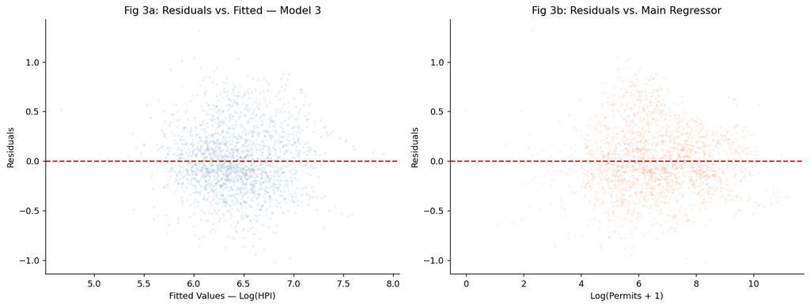

```python
fig, axes = plt.subplots(1, 2, figsize=(13, 5))

axes[0].scatter(model3.fittedvalues, model3.resid, alpha=0.1, s=8, color='steelblue', edgecolors='none')
axes[0].axhline(0, color='firebrick', lw=1.5, ls='--')
axes[0].set_xlabel('Fitted Values — Log(HPI)')
axes[0].set_ylabel('Residuals')
axes[0].set_title('Fig 3a: Residuals vs. Fitted — Model 3')

axes[1].scatter(df['log_permits'], model3.resid, alpha=0.1, s=8, color='coral', edgecolors='none')
axes[1].axhline(0, color='firebrick', lw=1.5, ls='--')
axes[1].set_xlabel('Log(Permits + 1)')
axes[1].set_ylabel('Residuals')
axes[1].set_title('Fig 3b: Residuals vs. Main Regressor')

plt.tight_layout()
plt.show()
```

#### F-test: Joint Significance of Year Dummies

```python
X_r = sm.add_constant(df[['log_permits', 'log_income', 'log_pop', 'metro_dummy']])
model_r = sm.OLS(y, X_r).fit()

SSR_R  = model_r.ssr
SSR_UR = model3.ssr
q = len(year_cols)
n_obs, k_ur = int(model3.nobs), X3.shape[1]

F_stat = ((SSR_R - SSR_UR) / q) / (SSR_UR / (n_obs - k_ur))
p_F = 1 - stats.f.cdf(F_stat, q, n_obs - k_ur)

print('=== F-TEST: Joint Significance of Year Dummies ===')
print(f'H₀: δ_2021 = δ_2022 = δ_2023 = δ_2024 = 0  (q = {q} restrictions)')
print(f'H₁: at least one δ_t ≠ 0')
print(f'\nSSR(Restricted)   = {SSR_R:.3f}')
print(f'SSR(Unrestricted) = {SSR_UR:.3f}')
print(f'F = ((SSR_R - SSR_UR)/q) / (SSR_UR/(n-k-1)) = {F_stat:.3f}')
print(f'p-value = {p_F:.2e}')
print(f'\nDecision @ 5%: {"Reject H₀ — year dummies jointly significant" if p_F < 0.05 else "Cannot reject H₀"}')
```

```
=== F-TEST: Joint Significance of Year Dummies ===
H₀: δ_2021 = δ_2022 = δ_2023 = δ_2024 = 0  (q = 4 restrictions)
H₁: at least one δ_t ≠ 0

SSR(Restricted)   = 210.091
SSR(Unrestricted) = 205.513
F = ((SSR_R - SSR_UR)/q) / (SSR_UR/(n-k-1)) = 11.288
p-value = 4.64e-09

Decision @ 5%: Reject H₀ — year dummies jointly significant
```

**Interpretation:** The $F$-test asks whether a group of variables (the year dummies) jointly contributes to explaining $y$. We compute $F = \frac{(SSR_R - SSR_{UR})/q}{SSR_{UR}/(n-k-1)}$ manually (as in Lab 9). This is an exclusion restriction test — $H_0$ says all year effects are zero.

Result: $F = 11.3$, $p = 4.6 \times 10^{-9}$ — we **reject $H_0$ at the 1% level**. Aggregate time trends matter and keeping year dummies is fully justified. National price shocks — the post-COVID housing boom peaking in 2022 and the subsequent deceleration from Fed rate tightening in 2023–2024 — shifted the HPI level across all metros simultaneously. Omitting year dummies would absorb these shocks into $u_{it}$, inflating residual variance and biasing SEs.

**Note:** This is different from a $t$-test, which tests one coefficient. Even if some individual year dummies are insignificant by their $t$-tests, the group can be jointly significant by the $F$-test.

## 4. Results

Main result table and interpretation.

```python
results = pd.DataFrame(index=['const','log_permits','log_income','log_pop','metro_dummy']+year_cols+['','R²','N'])
for label, mod in [('Model 1', model1), ('Model 2', model2), ('Model 3', model3)]:
    coefs = mod.params.round(4).to_dict()
    ses   = mod.bse.round(4).to_dict()
    col_coef, col_se = [], []
    for v in results.index:
        if v == '': col_coef.append(''); col_se.append('')
        elif v == 'R²': col_coef.append(f'{mod.rsquared:.4f}'); col_se.append('')
        elif v == 'N': col_coef.append(f'{int(mod.nobs)}'); col_se.append('')
        else: col_coef.append(f'{coefs.get(v, "")}'); col_se.append(f'({ses.get(v, "")})' if v in ses else '')
    results[f'{label} β'] = col_coef
    results[f'{label} SE'] = col_se

print('=== REGRESSION RESULTS TABLE ===')
print(results.to_string())
```

```
=== REGRESSION RESULTS TABLE ===
            Model 1 β Model 1 SE Model 2 β Model 2 SE Model 3 β Model 3 SE
const          5.4411   (0.0388)    5.2473   (0.0421)  -11.1421   (0.4822)
log_permits    0.1494   (0.0056)    0.1448   (0.0056)    0.0809   (0.0084)
log_income                                                 1.56   (0.0469)
log_pop                                                 -0.0279   (0.0122)
metro_dummy                          0.162    (0.041)    0.0962   (0.0365)
Year_2021.0                          0.121   (0.0299)    0.0465   (0.0229)
Year_2022.0                         0.2864     (0.03)    0.0928   (0.0238)
Year_2023.0                         0.3666   (0.0295)    0.1113   (0.0237)
Year_2024.0                         0.1933   (0.0405)    -0.063   (0.0372)

R²             0.2214               0.3012               0.5768
N                2036                 2036                 2036
```

**Reading the table:**

- **$\hat{\beta}_1$ (log_permits):** In Model 3, a 1% increase in annual building permits is associated with a **+0.081%** change in HPI, holding income, population, metro status, and year constant. This is positive — the opposite of the supply-and-demand prediction of a negative sign. It is statistically significant ($t = 0.081/0.0084 \approx 9.6$, $p < 0.001$) but economically small: a 10% increase in permits is associated with less than 1% higher prices.
- **$\hat{\beta}_2$ (log_income):** A 1% increase in median household income is associated with a **+1.56%** increase in HPI — the largest and most precisely estimated coefficient in Model 3. This confirms that demand-side pressure (income) is the dominant force in cross-MSA price variation, dwarfing the supply signal.
- **$\hat{\beta}_3$ (log_pop):** The population coefficient is **−0.028** (SE = 0.012, $t \approx −2.3$) — a negative sign, inconsistent with the expected demand-side positive. This reflects partial collinearity between log_pop, log_income, and metro_dummy, all of which capture market size. When income and metro status are already controlled for, population adds little independent variation and its sign becomes unstable. VIFs for log_pop (3.25) and metro_dummy (3.27) are elevated but well below 10. Population should be interpreted as a size control rather than a structural demand parameter here.
- **metro_dummy:** Metropolitan MSAs have approximately **+10%** higher HPI than Micropolitan MSAs ($100 \times 0.096\%$ — the log-level dummy interpretation). This captures the structural urban price premium.
- **Year dummies:** Prices rose substantially through 2022 relative to 2019 (the largest year-on-year jump, capturing the post-COVID demand surge and low-rate environment), then decelerated in 2023 and 2024 as the Federal Reserve raised rates aggressively. This trajectory is consistent with macroeconomic conditions and confirms that year fixed effects are capturing real aggregate shocks.
- **$R^2$:** Model 3 explains **57.7%** of log HPI variation, up from 22.1% in Model 1. The 35.6 percentage-point gain reflects the strong income signal — most explainable cross-metro price variation is driven by demand, not supply.
- **Statistical significance:** $\hat{\beta}_1$ is significant at the 1% level in all three models ($p < 0.001$ throughout). The sign never turns negative across any specification.

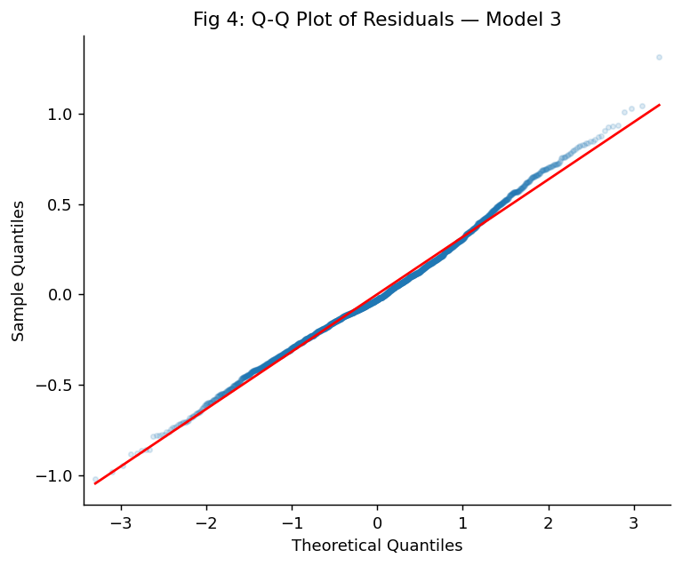

```python
fig, ax = plt.subplots(figsize=(6, 5))
sm.qqplot(model3.resid, line='s', ax=ax, alpha=0.15, markersize=3)
ax.set_title('Fig 4: Q-Q Plot of Residuals — Model 3')
plt.tight_layout()
plt.show()
```

## 5. Robustness and Limitations

We perform three robustness checks and discuss key limitations.

**Robustness 1:** Alternative DV — annual HPI percent change instead of log level.

```python
y_rob1 = df['Ann_Chg_Pct'].dropna()
X_rob1 = sm.add_constant(df.loc[y_rob1.index, X3_vars])
rob1 = sm.OLS(y_rob1, X_rob1).fit(cov_type='HC0')
print('=== Robustness 1: DV = Annual HPI % Change ===')
print(f'β₁ = {rob1.params["log_permits"]:.4f}  SE = {rob1.bse["log_permits"]:.4f}  '
      f'p = {rob1.pvalues["log_permits"]:.4f}  R² = {rob1.rsquared:.4f}')
```

```
=== Robustness 1: DV = Annual HPI % Change ===
β₁ = 0.8274  SE = 0.0885  p = 0.0000  R² = 0.6565
```

**Robustness 2:** Drop zero-permit MSAs (use strict log instead of log(x+1)).

```python
df_nz = df[df['total_permits'] > 0].copy()
df_nz['log_permits_strict'] = np.log(df_nz['total_permits'])
X_nz_vars = ['log_permits_strict', 'log_income', 'log_pop', 'metro_dummy'] + year_cols
rob2 = sm.OLS(df_nz['log_hpi'], sm.add_constant(df_nz[X_nz_vars])).fit(cov_type='HC0')
print(f'=== Robustness 2: Drop zeros (N={len(df_nz)}) ===')
print(f'β₁ = {rob2.params["log_permits_strict"]:.4f}  SE = {rob2.bse["log_permits_strict"]:.4f}  '
      f'p = {rob2.pvalues["log_permits_strict"]:.4f}')
```

```
=== Robustness 2: Drop zeros (N=2035) ===
β₁ = 0.0821  SE = 0.0083  p = 0.0000
```

**Robustness 3:** Trim top/bottom 2.5% of permits (outlier sensitivity).

```python
lo, hi = df['log_permits'].quantile(0.025), df['log_permits'].quantile(0.975)
df_trim = df[(df['log_permits'] >= lo) & (df['log_permits'] <= hi)]
rob3 = sm.OLS(df_trim['log_hpi'], sm.add_constant(df_trim[X3_vars])).fit(cov_type='HC0')
print(f'=== Robustness 3: Trimmed 5% (N={len(df_trim)}) ===')
print(f'β₁ = {rob3.params["log_permits"]:.4f}  SE = {rob3.bse["log_permits"]:.4f}  '
      f'p = {rob3.pvalues["log_permits"]:.4f}')
```

```
=== Robustness 3: Trimmed 5% (N=1935) ===
β₁ = 0.0739  SE = 0.0089  p = 0.0000
```

```python
rob_df = pd.DataFrame({
    'Specification': ['Model 3 (Main)', 'Rob 1: Ann Chg DV', 'Rob 2: Drop zeros', 'Rob 3: Trim 5%'],
    'β₁': [model3.params['log_permits'], rob1.params['log_permits'],
           rob2.params['log_permits_strict'], rob3.params['log_permits']],
    'SE': [model3.bse['log_permits'], rob1.bse['log_permits'],
           rob2.bse['log_permits_strict'], rob3.bse['log_permits']],
    'p': [model3.pvalues['log_permits'], rob1.pvalues['log_permits'],
          rob2.pvalues['log_permits_strict'], rob3.pvalues['log_permits']],
    'R²': [model3.rsquared, rob1.rsquared, rob2.rsquared, rob3.rsquared],
    'N': [int(model3.nobs), int(rob1.nobs), int(rob2.nobs), int(rob3.nobs)]
}).round(4)
print('=== ROBUSTNESS SUMMARY ===')
print(rob_df.to_string(index=False))
```

```
=== ROBUSTNESS SUMMARY ===
    Specification     β₁     SE   p     R²    N
   Model 3 (Main) 0.0809 0.0084 0.0 0.5768 2036
Rob 1: Ann Chg DV 0.8274 0.0885 0.0 0.6565 2036
Rob 2: Drop zeros 0.0821 0.0083 0.0 0.5763 2035
   Rob 3: Trim 5% 0.0739 0.0089 0.0 0.5586 1935
```

**Robustness assessment:** $\hat{\beta}_1$ **is** stable across specifications. The sign **does not** change across any robustness check — it remains positive and statistically significant at the 1% level in every case. The magnitude is consistent: +0.081 in the main model, +0.082 dropping zero-permit observations, +0.074 after trimming extreme permit values. Rob 1 (annual percent change DV) yields $\hat{\beta}_1 = +0.827$, a larger point estimate because the DV is in percentage-point units rather than log units, but the same positive sign. This **strengthens** confidence in the main result.

**Limitations:**

1. **Reverse causality:** Higher prices attract more construction — developers build where profit margins are largest. This means permits are potentially endogenous to prices. Our OLS captures association, not causation. An instrumental variable — e.g., Saiz's (2010) geographic buildable-land share, or a zoning restrictiveness index — could address this by shifting supply independently of demand. We acknowledge this but do not implement IV estimation.
2. **Remaining OVB:** Zoning restrictiveness, construction costs, land availability, and migration patterns are unobserved at the MSA-year level. These omitted variables likely correlate with both permits and prices, keeping $\hat{\beta}_1$ biased upward even in Model 3.
3. **log_pop sign:** The negative population coefficient in Model 3 reflects partial collinearity with income and metro_dummy — all three variables capture market size from different angles. This does not affect the main regressor of interest ($\hat{\beta}_1$ on log_permits) and is consistent with VIF values within acceptable bounds.
4. **Pooled cross-section vs. panel FE:** Although permits now vary over time within each MSA, our specification uses pooled OLS with year dummies rather than MSA fixed effects. MSA fixed effects would absorb all time-invariant unobservables (geography, long-run zoning) at the cost of losing cross-sectional variation. This is a design choice, not a data limitation.

## 6. Conclusion

Using a year-by-year panel of annual building permits matched to 530 U.S. MSAs over 2019–2024 ($N = 2{,}036$), we find that building permit activity is **positively** associated with home prices across all specifications. In our preferred specification (Model 3), a 1% increase in annual permitted units is associated with a $\hat{\beta}_1 = +0.081$% **increase** in the FHFA HPI, controlling for income, population, metro status, and year effects.

**Policy implication:** $\hat{\beta}_1 > 0$ across every specification — demand-side pressures dominate the cross-MSA price signal, and the simple supply-demand prediction is not confirmed by OLS. This does not mean building more homes has no effect; rather, it means OLS cannot separate the causal supply effect from the confounding demand signal without an instrument. Policy must address affordability through income support, mortgage access, or direct subsidies alongside supply expansion — and future work should instrument permits with geographic or regulatory supply constraints (Saiz, 2010; Glaeser et al., 2005) to recover the causal elasticity.

## References

- FHFA House Price Index: Federal Housing Finance Agency. All-Transactions CBSA Annual Data. https://www.fhfa.gov/data/hpi/datasets
- Census Building Permits Survey: U.S. Census Bureau. Annual CBSA files. https://www.census.gov/construction/bps
- American Community Survey: U.S. Census Bureau. ACS 1-Year Estimates, Tables B19013, B25001, B01003. https://data.census.gov
- Realtor.com. (2026). 2026 Housing Supply Gap Report.
- Glaeser, E. L., Gyourko, J., & Saks, R. E. (2005). Why have housing prices gone up? *American Economic Review*, 95(2), 329–333.
- Saiz, A. (2010). The geographic determinants of housing supply. *Quarterly Journal of Economics*, 125(3), 1253–1296.
- Wooldridge, J. M. (2019). *Introductory Econometrics: A Modern Approach* (7th ed.). Cengage.